# Statistical Inference: non-parametric statistics - Wilcoxon-Mann-Withney test

Lieven Clement

statOmics, Ghent University (https://statomics.github.io)

# 1 Comparison of $g$ groups

- Extend $F$-test from a one-way ANOVA to non-parametric alternatives.

# 2 DMH Voorbeeld

Assess genotoxicity of 1,2-dimethylhydrazine dihydrochloride (DMH) (EU directive)

- 24 rats
- four groups with daily DMH dose
- control
- low
- medium
- high
- Genotoxicity in liver using comet assay on 150 liver cells per rat.
- Are there differences in DNA damage due to DMH dose?

## 2.1 Comet Assay:

- Visualise DNA strand breaks
- Length comet tail is a proxy for strand breaks.

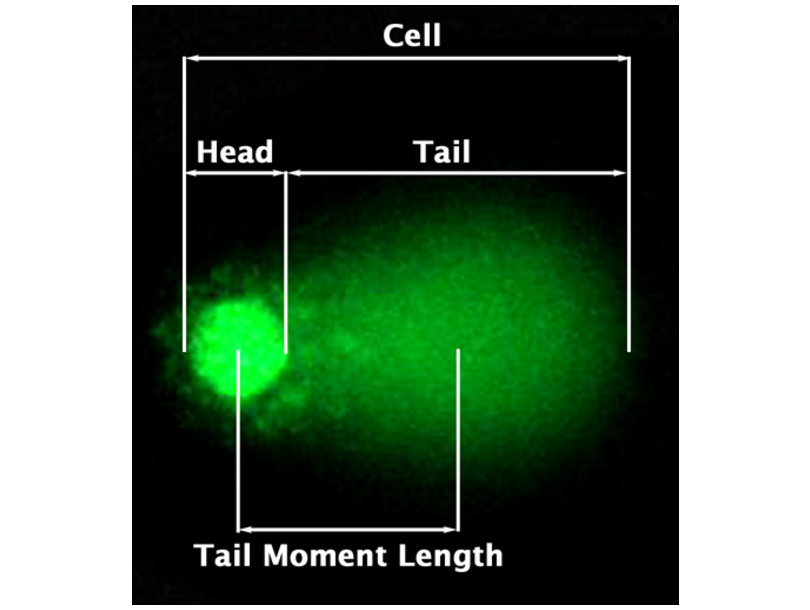

Comet assay

```r
dna <- read_delim("https://raw.githubusercontent.com/GTPB/PSLS20/master/data/dna.txt",delim=" ")
dna$dose <- as.factor(dna$dose)
dna
```

```
# A tibble: 24 x 3
   id    length dose
   <chr>  <dbl> <fct>
 1 Rat1    19.3 0
 2 Rat2    18.9 0
 3 Rat3    18.6 0
 4 Rat4    19.0 0
 5 Rat5    17.1 0
 6 Rat6    18.8 0
 7 Rat7    55.4 1.25
 8 Rat8    59.2 1.25
 9 Rat9    59.1 1.25
10 Rat10   52.1 1.25
# ... with 14 more rows
```

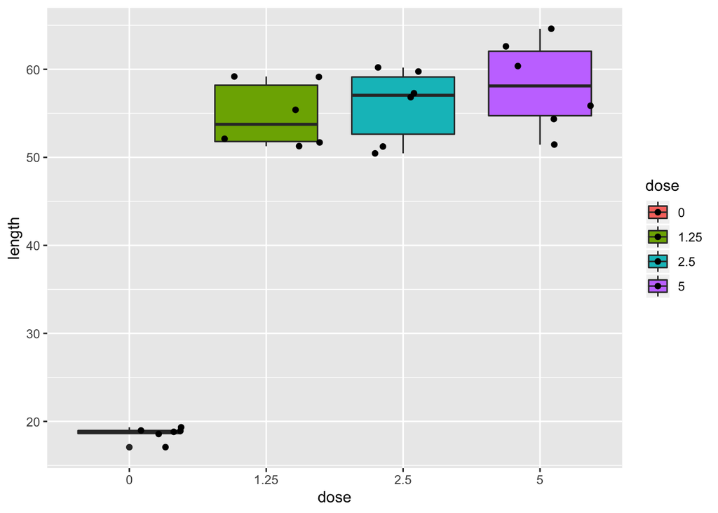

```r
dna %>%
  ggplot(aes(x=dose,y=length,fill=dose))+
  geom_boxplot() +
  geom_point(position="jitter")
```

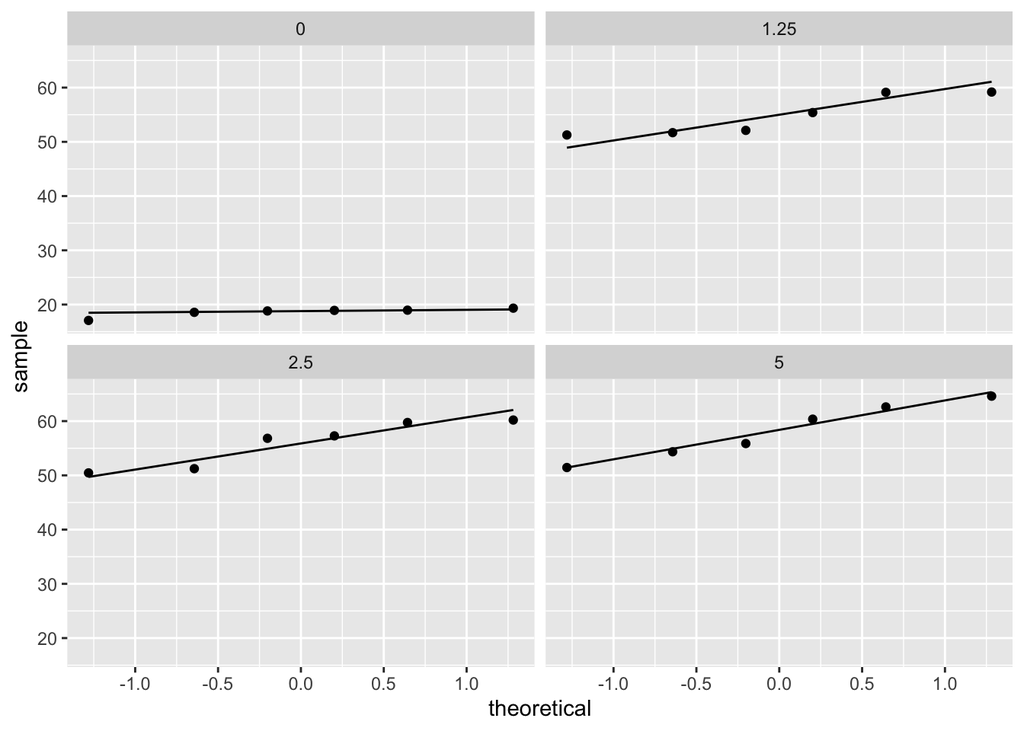

```r
dna %>%
  ggplot(aes(sample=length)) +
  geom_qq() +
  geom_qq_line() +
  facet_wrap(~dose)
```

- Strong indication that data in control group has a lower variance.
- 6 observations per group are too few to check the assumptions

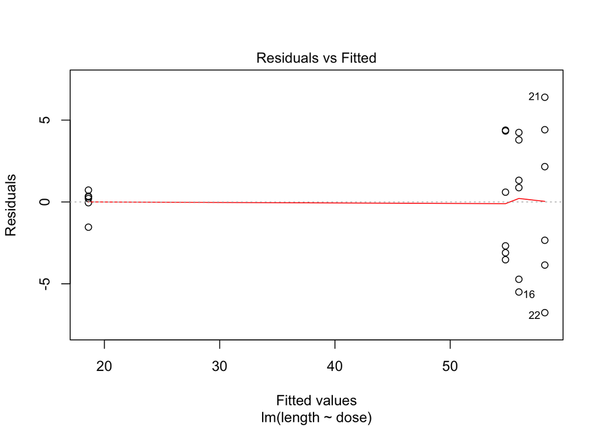

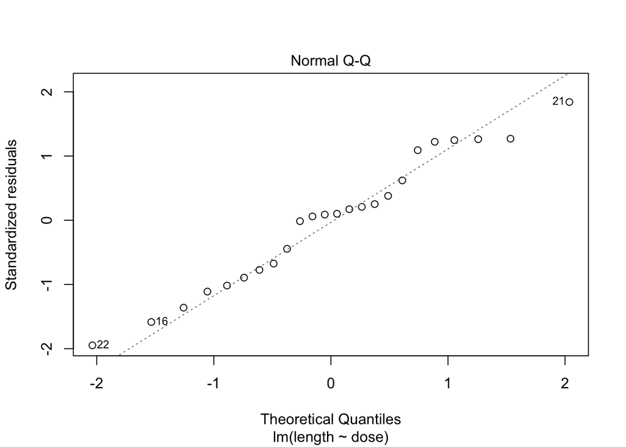

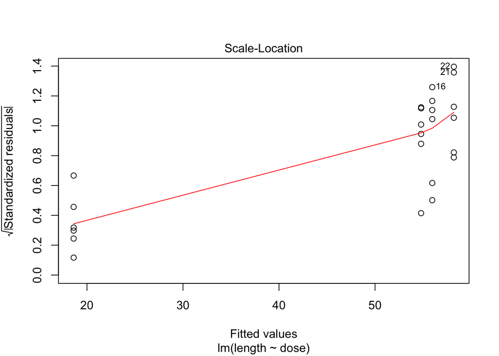

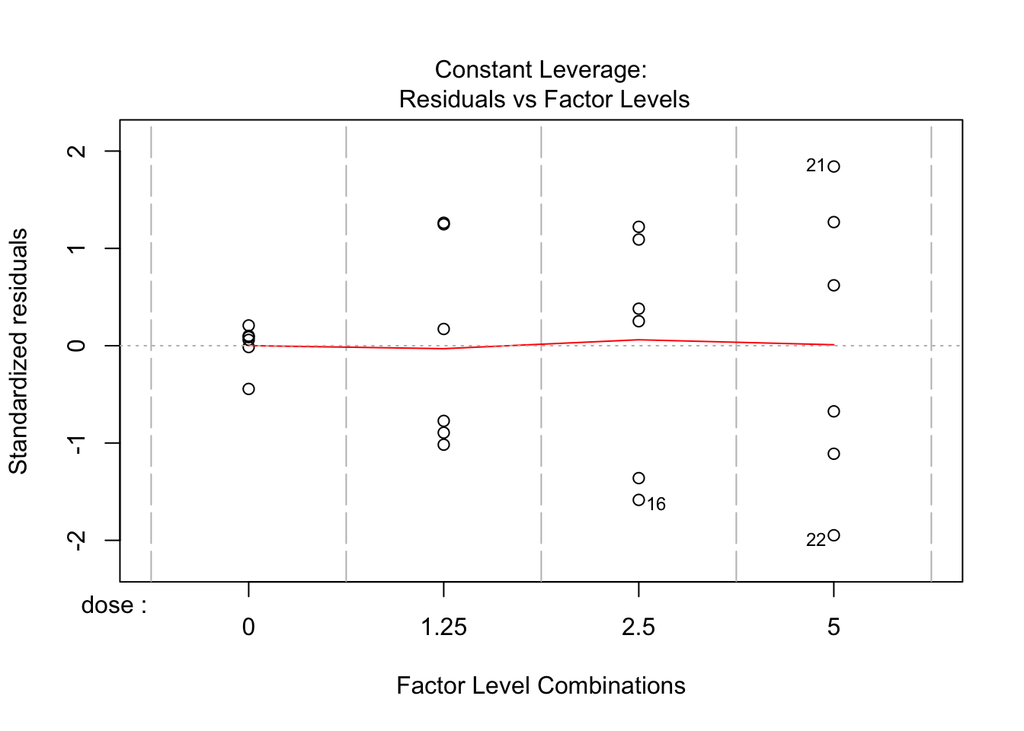

```r
plot(lm(length~dose,data=dna))
```

# 3 Kruskal-Wallis Rank Test

- The Kruskal-Wallis Rank Test (KW-test) is a non-parameteric alternative for ANOVA F-test.
- Classical $F$-teststatistic can be written as
  $$F = \frac{\text{SST}/(g-1)}{\text{SSE}/(n-g)} = \frac{\text{SST}/(g-1)}{(\text{SSTot}-\text{SST})/(n-g)} ,$$
- with $g$ the number of groups.
- SSTot depends only on outcomes $\mathbf{y}$ and will not vary in permutation test.
- SST can be used as statistic
  $$\text{SST}=\sum_{j=1}^t n_j(\bar{Y}_j-\bar{Y})^2$$
- The KW test statistic is based on SST on rank-transformed outcomes[^1],
  $$\text{SST} = \sum_{j=1}^g n_j \left(\bar{R}_j - \bar{R}\right)^2 = \sum_{j=1}^t n_j \left(\bar{R}_j - \frac{n+1}{2}\right)^2 ,$$
- with $\bar{R}_j$ the mean of the ranks in group $j$, and $\bar{R}$ the mean of all ranks,
  $$\bar{R} = \frac{1}{n}(1+2+\cdots + n) = \frac{1}{n}\frac{1}{2}n(n+1) = \frac{n+1}{2}.$$
- The KW teststatistic is given by
  $$KW = \frac{12}{n(n+1)} \sum_{j=1}^g n_j \left(\bar{R}_j - \frac{n+1}{2}\right)^2.$$
- The factor $\frac{12}{n(n+1)}$ is used so that $KW$ has a simple asymptotic null distribution. In particular under $H_0$, given thart $\min(n_1,\ldots, n_g)\rightarrow \infty$,
  $$KW \rightarrow \chi^2_{t-1}.$$
- The exact KW-test can be executed by calculating the permutation null distribution (that only depends on $n_1, \ldots, n_g$) to test
  $$H_0: f_1=\ldots=f_g \text{ vs } H_1: \text{ at least two means are different}.$$
- In order to allow $H_1$ to be formulated in terms of means, the assumption of locations shift should be valid.
- For DMH example this is not the case.
- If location-shift is invalid, we have to formulate $H_1$ in terms of probabilistic indices:
  $$H_0: f_1=\ldots=f_g \text{ vs } H_1: \exists\ j,k \in \{1,\ldots,g\} : \text{P}\left[Y_j\geq Y_k\right]\neq 0.5$$

## 3.1 DNA Damage Example

```r
kruskal.test(length~dose,data=dna)
```

```
    Kruskal-Wallis rank sum test

data:  length by dose
Kruskal-Wallis chi-squared = 14, df = 3, p-value = 0.002905
```

- On the $5\%$ level of significance we can reject the null hypothesis.
- R-functie `kruskal.test` only returns the asymptotic approximation for $p$-values.
- With only 6 observaties per groep, this is not a good approximation of the $p$-value
- With the `coin` R package we can calculate the exacte $p$-value

```r
library(coin)
kwPerm <- kruskal_test(length~dose,data=dna,
            distribution=approximate(B=100000))
kwPerm
```

```
    Approximative Kruskal-Wallis Test

data:  length by dose (0, 1.25, 2.5, 5)
chi-squared = 14, p-value = 0.00039
```

- We conclude that the difference in the distribution of the DNA damages due to the DMH dose is extremely significantly different.
- Posthoc analysis with WMW tests.

```r
pairwise.wilcox.test(dna$length,dna$dose)
```

```
    Pairwise comparisons using Wilcoxon rank sum test

data:  dna$length and dna$dose

     0     1.25  2.5
1.25 0.013 -     -
2.5  0.013 0.818 -
5    0.013 0.721 0.788

P value adjustment method: holm
```

- All DMH behandelingen are significantly different from the control.
- The DMH are not significantly different from one another.
- U1 does not occur in the `pairwise.wilcox.test` output. Point estimate on probability on higher DNA-damage?

```r
nGroup <- table(dna$dose)
probInd <- combn(levels(dna$dose),2,function(x)
         {
         test <- wilcox.test(length~dose,subset(dna,dose%in%x))
         return(test$statistic/prod(nGroup[x]))
         }
         )
names(probInd) <- combn(levels(dna$dose),2,paste,collapse="vs")
probInd
```

```
  0vs1.25    0vs2.5      0vs5 1.25vs2.5   1.25vs5    2.5vs5
0.0000000 0.0000000 0.0000000 0.4444444 0.2777778 0.3333333
```

Because there are doubts on the location-shift model we draw our conclusions in terms of the probabilistic index.

### 3.1.1 Conclusion

- There is an extremely significant difference in in the distribution of the DNA-damage measurements due to the treatment with DMH ($p<0.001$ KW-test).
- DNA-damage is more likely upon DMH treatment than in the control treatment (all p=0.013, WMW-testen).
- The probability on higher DNA-damage upon exposure to DMH is 100% (Calculation of a CI on the probabilistic index is beyond the scope of the course)
- There are no significant differences in the distributions of the comit-lengths among the treatment with the different DMH concentrations ($p=$ 0.72-0.82).
- DMH shows already genotoxic effects at low dose.
- (Alle paarswise tests are gecorrected for multiple testing using Holm’s methode).
[^1]: we assume that no *ties* are available